# R Notebook

#Data exploration Load the required libraries for data analysis.

```r
library(readxl)
library(dplyr)
library(ggplot2)
library(CMA)
```

```r
dim(BOLT_Data_Set)
```

```
[1] 100000     14
```

```r
head(BOLT_Data_Set)
```

| Card Identifier | Transaction Date | Transaction Time | Risk Assessment | Payment Method | Transaction Value | Merchant Location | Card Present Status | Chip Usage | Cross-border Transaction (Yes/No) | Acquiring Institution ID | Merchant Identifier | Merchant Category Code (MCC) | Fraud Indicator (Yes/No) |
| --- | --- | --- | --- | --- | --- | --- | --- | --- | --- | --- | --- | --- | --- |
| card 1 | 2023-05-11 | 16:22:14.0 | 362 | Paypass - Contactless | 13.98 | USA | CP | Yes | No | acquirer 1 | merchant 1 | 5812 | No |
| card 2 | 2023-06-05 | 15:16:35.0 | 602 | Online | 24.64 | USA | CNP | No | No | acquirer 2 | merchant 2 | 4121 | No |
| card 3 | 2023-06-05 | 11:57:40.0 | 482 | Unknown | 15.00 | USA | CNP | No | No | acquirer 3 | merchant 3 | 7211 | No |
| card 4 | 2023-07-20 | 18:26:30.0 | 947 | Online | 30.56 | USA | CNP | No | No | acquirer 1 | merchant 4 | 5814 | No |
| card 5 | 2023-03-03 | 19:03:11.0 | 1382 | Magnetic Stripe | 50.85 | USA | CP | No | No | acquirer 4 | merchant 1 | 5812 | No |
| card 6 | 2023-07-22 | 18:04:28.0 | 612 | Paypass - Contactless | 75.77 | USA | CP | Yes | No | acquirer 5 | merchant 1 | 5812 | No |

```r
#Convert the date type from characters to factors
BOLT <- BOLT_Data_Set %>%
  filter(!(`Cross-border Transaction (Yes/No)` == 0)) %>%
  mutate_if(is.character, as.factor)
```

```r
#loos at the summary of the dataset.
summary(BOLT)
```

[output not shown]

## Business analytics

### Which location(country) has the highest number of transaction and total transaction value?

```r
spend_location <- BOLT %>%
  group_by(`Merchant Location`) %>%
  summarise(number_of_transaction = n(), total_transaction_value = sum(`Transaction Value`)) %>%
  arrange(desc(total_transaction_value))
top10 <- head(spend_location, 10)
Other <- spend_location[11: nrow(spend_location), ] %>%
         summarise(number_of_transaction = sum(number_of_transaction), total_transaction_value = sum(total_transaction_value)) %>%
        mutate(`Merchant Location` = "other")
(spend_location <- rbind(top10, Other))
```

| Merchant Location | number_of_transaction | total_transaction_value |
| --- | --- | --- |
| USA | 85155 | 5771085.52 |
| GBR | 3573 | 226473.67 |
| FRA | 1425 | 149472.34 |
| ESP | 1018 | 99816.47 |
| GRC | 265 | 85210.28 |
| ITA | 586 | 83903.16 |
| MEX | 705 | 57265.38 |
| NLD | 775 | 48013.32 |
| CAN | 644 | 43761.37 |
| IRL | 400 | 38089.10 |

[output cut: 1 more lines]

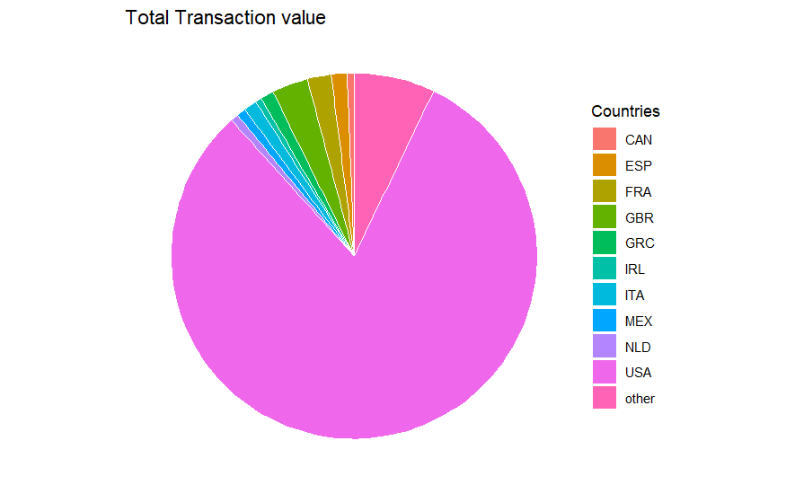

```r
ggplot(spend_location, aes(x = "", y = `total_transaction_value`, fill = `Merchant Location`)) +
  geom_bar(stat = "identity", width = 1, color = "white") +
  coord_polar("y", start = 0) +
  theme_void() +
  labs(title = "Total Transaction value ", fill = "Countries")
```

Business recommendation: increase marketing budget in the locations with low numbers.

###Which type of merchants are using the most of the service in the US?

```r
BOLT %>%
  filter(`Merchant Location` == "USA") %>%
  group_by(`Merchant Category Code (MCC)`) %>%
  summarise(number_of_transaction = n(), total_transaction_value = sum(`Transaction Value`)) %>%
  arrange(desc(total_transaction_value))
```

| Merchant Category Code (MCC) | number_of_transaction | total_transaction_value |
| --- | --- | --- |
| 5812 | 14194 | 613745.26 |
| 4829 | 3354 | 543500.26 |
| 6513 | 224 | 305327.02 |
| 5411 | 4214 | 203051.62 |
| 5814 | 10512 | 157583.42 |
| 7299 | 973 | 141544.75 |
| 4722 | 333 | 121607.14 |
| 5999 | 2115 | 120577.87 |
| 6300 | 520 | 117255.92 |
| 5942 | 2963 | 110450.03 |

[output cut: 338 more lines]

### When do people spend the most during the year?

```r
timeseries <- BOLT %>%
  group_by(`Transaction Date`) %>%
  summarise(total_transactions = sum(`Transaction Value`))

ggplot(timeseries, aes(x = `Transaction Date`, y = total_transactions)) +
  geom_point() +  # Add scatter plot points
  geom_smooth(method = "loess", se = TRUE, color = "red") +  # Add a trend line
  labs(title = "Total Transactions Over Time", y = "Total Transactions in Dollars")
```

[output not shown]

```r
timeseries2 <- BOLT %>%
  group_by(day(BOLT$`Transaction Date`)) %>%
  summarise(total_transactions = sum(`Transaction Value`))


barplot(timeseries2$total_transactions ~ timeseries2$`day(BOLT$\`Transaction Date\`)`,
        xlab = "Day of the month", ylab = "Total transaction", main = "Daily total transaction", col = c("red","blue", "green"))
```

[output not shown]

## Variables associated with increased risk of frauds

### Which location have the highest proportion of transactions being fraud?

```r
BOLT %>%
  group_by(`Merchant Location`) %>%
  summarise(num_of_transaction = n(), num_of_fraud = sum(`Fraud Indicator (Yes/No)` == "Yes")) %>%
  mutate(proportion_of_fraud = num_of_fraud / num_of_transaction) %>%
  arrange(desc(proportion_of_fraud), desc(num_of_fraud))
```

| Merchant Location | num_of_transaction | num_of_fraud | proportion_of_fraud |
| --- | --- | --- | --- |
| GIB | 4 | 2 | 0.5000000000 |
| LBN | 18 | 7 | 0.3888888889 |
| KEN | 8 | 1 | 0.1250000000 |
| FIN | 11 | 1 | 0.0909090909 |
| SGP | 203 | 15 | 0.0738916256 |
| IND | 29 | 2 | 0.0689655172 |
| ECU | 20 | 1 | 0.0500000000 |
| PER | 21 | 1 | 0.0476190476 |
| ISL | 32 | 1 | 0.0312500000 |
| DOM | 33 | 1 | 0.0303030303 |

[output cut: 127 more lines]

Can put these merchant location as high risk factor. However, the sample size is small for these locations so it is not really conclusive.

### Which payment methods have the most fraud?

```r
BOLT %>%
  group_by(`Payment Method`) %>%
  summarise(num_of_fraud = sum(`Fraud Indicator (Yes/No)` == "Yes")) %>%
  arrange(desc(num_of_fraud))
```

| Payment Method | num_of_fraud |
| --- | --- |
| Online | 140 |
| Subscription | 58 |
| Paypass - Contactless | 22 |
| Magnetic Stripe | 16 |
| Chip | 12 |
| Unknown | 8 |
| Phone | 5 |
| PayPass - Wallet | 4 |
| eCommerce | 0 |
| Mobile Wallet | 0 |

[output cut: 2 more lines]

We see that most fraud are through online and subsription payment.

### When does fraud transaction often take place?

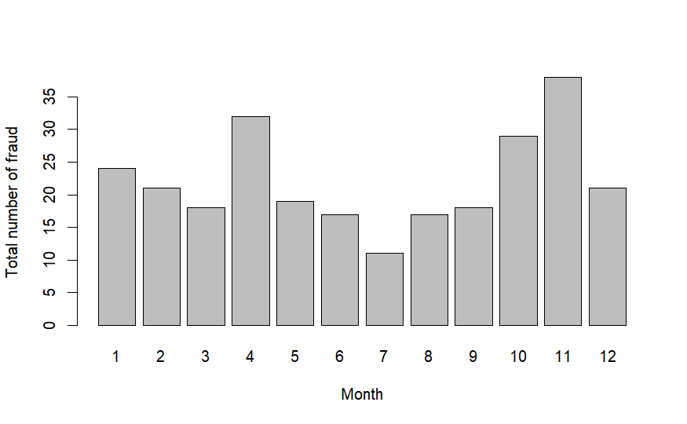

```r
fraud_month <- BOLT %>%
  group_by(month(BOLT$`Transaction Date`)) %>%
  filter(`Fraud Indicator (Yes/No)` == "Yes" ) %>%
  summarise(num_of_fraud = n())
barplot(fraud_month$num_of_fraud ~ fraud_month$`month(BOLT$\`Transaction Date\`)`, xlab = "Month", ylab = "Total number of fraud")
```

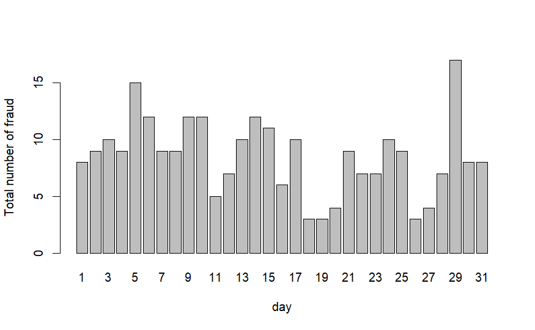

```r
fraud_day <- BOLT %>%
  group_by(day(BOLT$`Transaction Date`)) %>%
  filter(`Fraud Indicator (Yes/No)` == "Yes" ) %>%
  summarise(num_of_fraud = n())
barplot(fraud_day$num_of_fraud ~ fraud_day$`day(BOLT$\`Transaction Date\`)`, xlab = "day", ylab = "Total number of fraud")
```

The fraud happened the most in the month of November, follow by April.

### Does cross-border transaction reprensents a higher risk of fraud transaction?

```r
BOLT %>%
  group_by(`Cross-border Transaction (Yes/No)`) %>%
  summarise(number_of_transaction = n(), fraud = sum(`Fraud Indicator (Yes/No)` == "Yes"), Non_fraud = sum(`Fraud Indicator (Yes/No)` == "No"))
```

| Cross-border Transaction (Yes/No) | number_of_transaction | fraud | Non_fraud |
| --- | --- | --- | --- |
| No | 85037 | 174 | 84863 |
| Yes | 14845 | 91 | 14754 |

Yes, the ratio of fraud is higher for the Cross-border Transaction:
$$\frac{91}{91 + 14754} \approx 0.00613 >
0.002050364 \approx \frac{174}{174 + 84863}$$
One can also use chi-square statistics to test if this differnce in ratio is signifcant.

```r
contingency_table <- as.table(rbind(c(91, 174), c(14754, 84863)))
dimnames(contingency_table) <- list(Fraud = c("Yes", "No"), Crossborder = c("Yes","No") )
print(contingency_table)
chisq.test(contingency_table)
```

[output not shown]

### Does chip usage and physical card usage during the payment decreases the risk of fraud?

```r
BOLT %>%
  group_by(`Card Present Status`, `Chip Usage`) %>%
  summarise(fraud = sum(`Fraud Indicator (Yes/No)` == "Yes"), Non_fraud = sum(`Fraud Indicator (Yes/No)` == "No"), ratio_of_fraud = fraud / (fraud + Non_fraud) )
```

| Card Present Status | Chip Usage | fraud | Non_fraud | ratio_of_fraud |
| --- | --- | --- | --- | --- |
| CNP | No | 211 | 49882 | 0.0042121654 |
| CNP | Yes | 0 | 9 | 0.0000000000 |
| CP | No | 17 | 4082 | 0.0041473530 |
| CP | Yes | 37 | 45644 | 0.0008099648 |

We see that these variables are correlated in some way - most non-physical card user also don’t have chip usage, and vice versa.  
The ratio of fraud for the physical card and Chip usage is $37 / 45681 \approx 0.0008$, which is significantly lower than the non-user $211/50093 \approx 0.0042$. Also, it is not enough to only use physical card but not the chip - by looking at the group of non-chip usage, the use of physical card does not change the ratio of fraud by much (0.00421 vs. 0.00415).

```r
contingency_table <- as.table(rbind(c(37, 211), c(45644, 49882)))
dimnames(contingency_table) <- list(Fraud = c("Yes", "No"), ChipUsage = c("Yes","No") )
print(contingency_table)
```

```
     ChipUsage
Fraud   Yes    No
  Yes    37   211
  No  45644 49882
```

```r
chisq.test(contingency_table)
```

```
    Pearson's Chi-squared test with Yates' continuity correction

data:  contingency_table
X-squared = 105.77, df = 1, p-value < 2.2e-16
```

The chi-squared test indicates that chip usage and physical card significantly decrease the risk of fraud. Based on this, we recommend the business to increase the use of physical card and chip usage to minimize lost from fraud.

### Does the risk assessment accurately predict the risk of fraud? Does the fraud transaction has higher or lower average transaction value?

```r
BOLT %>%
  group_by(`Fraud Indicator (Yes/No)`) %>%
  summarise(`average risk assessment` = mean(`Risk Assessment`, na.rm = TRUE),
            `average transaction` = mean(`Transaction Value`, na.rm = TRUE))
```

[output not shown]

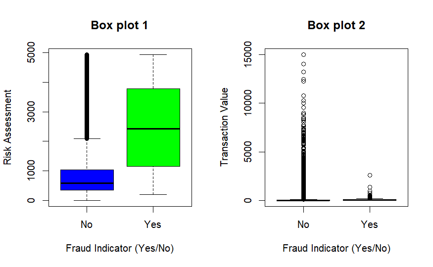

```r
par(mfrow = c(1, 2))
boxplot(`Risk Assessment` ~ `Fraud Indicator (Yes/No)`, data = BOLT, main = "Box plot 1", col = c("blue", "green") )
boxplot(`Transaction Value` ~ `Fraud Indicator (Yes/No)`, data = BOLT, main = "Box plot 2", col = c("blue", "green"))
```

By visual inspection of box plot 1, we see that average risk assessment is higher for the fraud group. However, we also see many outlier for the non-fraud group - that is, many non-fraud transactions are assigned high risk assessment. If we use only risk assessment to predict fraud, this could result in many false-positive.

The box plot 2 tells a similar story - although the average transaction is higher for the fraud group, we see that many non-fraud has very high transaction value. Also, the transaction value is below $5000$ for all the fraud transaction.

We can use t-test to test is the mean differences are really significant.

```r
t.test(`Risk Assessment` ~ `Fraud Indicator (Yes/No)`, data = BOLT)
t.test(`Transaction Value` ~ `Fraud Indicator (Yes/No)`, data = BOLT)
```

[output not shown]

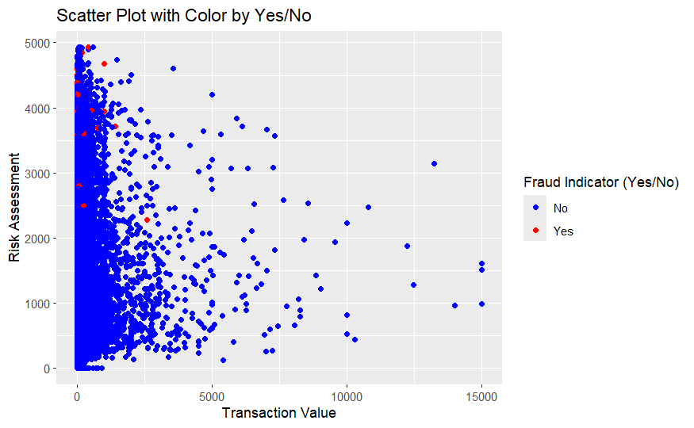

```r
#Visualize the relationship between transaction value and risk assessment by scatterplot
ggplot(BOLT, aes(x = `Transaction Value`, y = `Risk Assessment`, color = `Fraud Indicator (Yes/No)`)) +
  geom_point() +
  labs(title = "Scatter Plot with Color by Yes/No", x = "Transaction Value", y = "Risk Assessment") +
  scale_color_manual(values = c("Yes" = "red", "No" = "blue"))
```